# artData

Autogenerated data summary from dataMaid

2018-05-11 01:01:51

# Data report overview

The dataset examined has the following dimensions:

| Feature | Result |
| --- | --- |
| Number of observations | 200 |
| Number of variables | 11 |

### Checks performed

The following variable checks were performed, depending on the data type of each variable:

|  | character | factor | labelled | numeric | integer | logical | Date |
| --- | --- | --- | --- | --- | --- | --- | --- |
| Identify miscoded missing values | × | × | × | × | × |  | × |
| Identify prefixed and suffixed whitespace | × | × | × |  |  |  |  |
| Identify levels with < 6 obs. | × | × | × |  |  |  |  |
| Identify case issues | × | × | × |  |  |  |  |
| Identify misclassified numeric or integer variables | × | × | × |  |  |  |  |
| Identify non-trailing colons | × | × | × |  |  |  |  |
| Identify outliers |  |  |  | × | × |  | × |

Please note that all numerical values in the following have been rounded to 2 decimals.

# Summary table

|  | Variable class | # unique values | Missing observations | Any problems? |
| --- | --- | --- | --- | --- |
| ArtistID | character | 179 | 0.00 % | × |
| ArtistName | character | 179 | 0.00 % | × |
| NoOfMiddlenames | numeric | 4 | 0.00 % | × |
| Title | character | 200 | 0.00 % | × |
| Year | integer | 149 | 0.00 % | × |
| Location | character | 98 | 1.50 % | × |
| Continent | factor | 3 | 0.00 % | × |
| Width | numeric | 164 | 5.00 % | × |
| Height | numeric | 165 | 5.00 % | × |
| Media | character | 28 | 5.00 % | × |
| Movement | character | 86 | 9.00 % | × |

# Variable list

## ArtistID

- Warning: This variable seems to contain ID codes.

## ArtistName

| Feature | Result |
| --- | --- |
| Variable type | character |
| Number of missing obs. | 0 (0 %) |
| Number of unique values | 179 |
| Mode | “Diego Velazquez” |
| No. zeros | 0 |

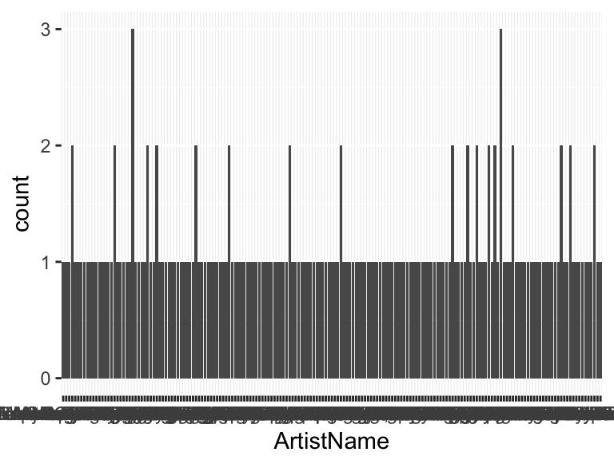

- The following values appear with prefixed or suffixed white space: "Giuseppe Arcimboldo ".
- Note that the following levels have at most five observations: "Adolph von Menzel", "Alberto Giacometti", "Albrecht Altdorfer", "Albrecht Durer", "Alexej von Jawlensky", "Andrea Mantegna", "Andrew Wyeth", "Annibale Carracci", "Anthony van Dyck", "Antoine Watteau" (169 additional values omitted).

## NoOfMiddlenames

- Note that this variable is treated as a factor variable below, as it only takes a few unique values.

| Feature | Result |
| --- | --- |
| Variable type | numeric |
| Number of missing obs. | 0 (0 %) |
| Number of unique values | 4 |
| Mode | “0” |
| No. zeros | 157 |

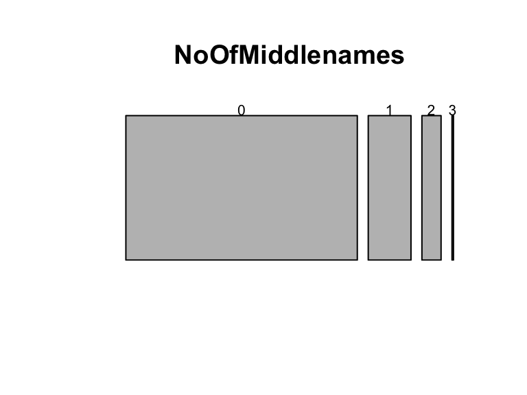

- Note that the following levels have at most five observations: "3".

## Title

- The variable is a key (distinct values for each observation).

## Year

| Feature | Result |
| --- | --- |
| Variable type | integer |
| Number of missing obs. | 0 (0 %) |
| Number of unique values | 149 |
| Median | 1851.5 |
| 1st and 3rd quartiles | 1627.75; 1914 |
| Min. and max. | 1150; 1968 |
| No. zeros | 0 |
| Mean | 1765.73 |

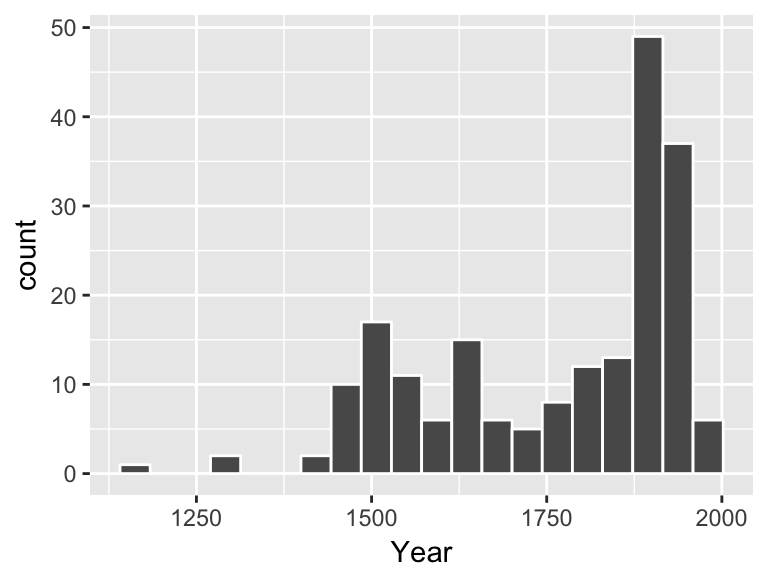

- Note that the following possible outlier values were detected: "1958", "1961", "1965", "1968".

## Location

| Feature | Result |
| --- | --- |
| Variable type | character |
| Number of missing obs. | 3 (1.5 %) |
| Number of unique values | 97 |
| Mode | “National Gallery” |
| No. zeros | 0 |

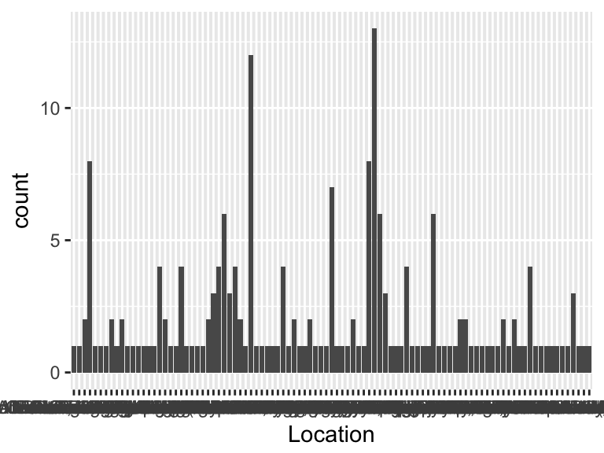

- Note that the following levels have at most five observations: "Alfred Stieglitz Collection, Carl Van Vechten Gallery", "Alte Nationalgalerie", "Alte Pinakothek", "Brancacci Chapel", "Centre Pompidou", "Christie’s Auction House", "Cleveland Museum of Art", "Courtauld Institute of Art, University of London", "Detroit Institute of Arts", "Fogg Museum" (79 additional values omitted).

## Continent

| Feature | Result |
| --- | --- |
| Variable type | factor |
| Number of missing obs. | 0 (0 %) |
| Number of unique values | 3 |
| Mode | “Europe” |
| No. zeros | 0 |

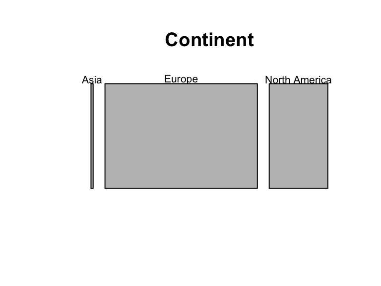

- Note that the following levels have at most five observations: "Asia".

## Width

| Feature | Result |
| --- | --- |
| Variable type | numeric |
| Number of missing obs. | 10 (5 %) |
| Number of unique values | 163 |
| Median | 122.45 |
| 1st and 3rd quartiles | 77; 198.3 |
| Min. and max. | 10.7; 990 |
| No. zeros | 0 |
| Mean | 168.46 |

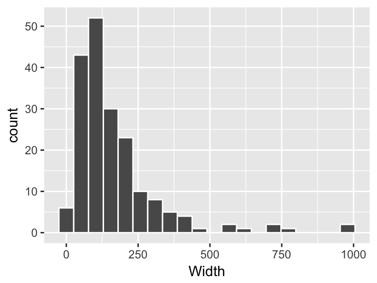

- Note that the following possible outlier values were detected: "10.7", "13.9", "14.7", "15.2", "17.2", "25", "26", "27", "28", "32" (3 additional values omitted).

## Height

| Feature | Result |
| --- | --- |
| Variable type | numeric |
| Number of missing obs. | 10 (5 %) |
| Number of unique values | 164 |
| Median | 113 |
| 1st and 3rd quartiles | 73.12; 168.75 |
| Min. and max. | 12.3; 666 |
| No. zeros | 0 |
| Mean | 134.51 |

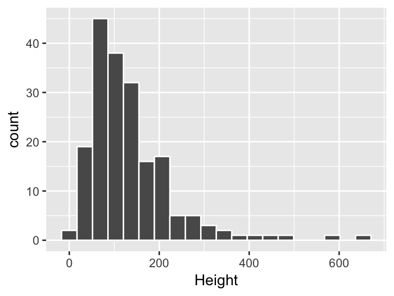

- Note that the following possible outlier values were detected: "460", "491", "585", "666".

## Media

| Feature | Result |
| --- | --- |
| Variable type | character |
| Number of missing obs. | 10 (5 %) |
| Number of unique values | 27 |
| Mode | “oil paint” |
| No. zeros | 0 |

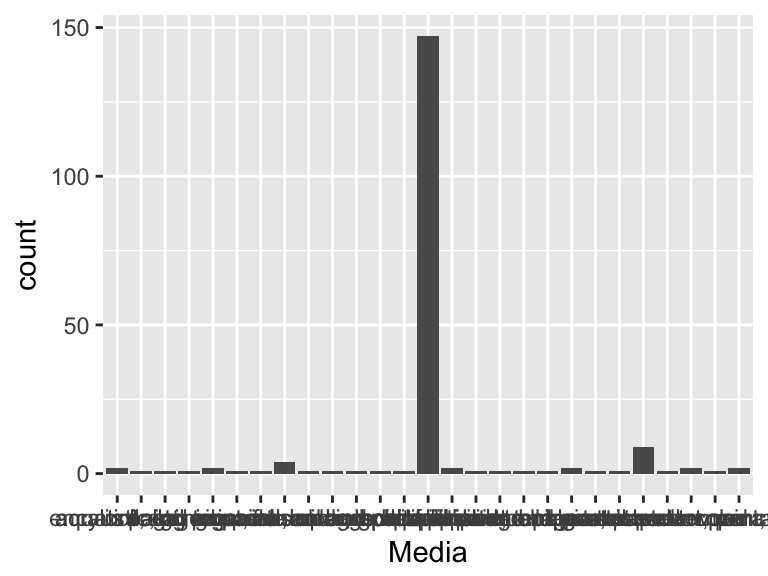

- Note that the following levels have at most five observations: "acrylic paint", "aquatint, etching", "collage", "collage, oil paint", "egg tempera", "enamel", "encaustic, oil paint, and collage on fabric", "fresco", "gouache and graphite", "gouache-painted paper" (15 additional values omitted).

## Movement

| Feature | Result |
| --- | --- |
| Variable type | character |
| Number of missing obs. | 18 (9 %) |
| Number of unique values | 85 |
| Mode | “Baroque” |
| No. zeros | 0 |

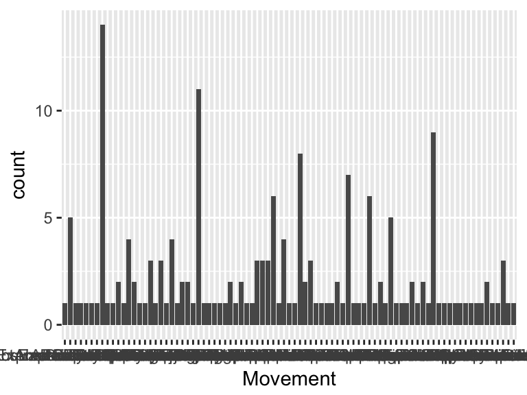

- Note that the following levels have at most five observations: "Abstract Artist", "Abstract Expressionist", "Abstract Expressionist:Color Field", "Abstract Expressionist:Neo-Dada:Pop Art", "American Modernist", "American Realist", "Analytic Cubist", "Bauhaus", "British Expressionist", "Classicist:Baroque" (68 additional values omitted).
- Note that the following values include colons: "Abstract Expressionist:Color Field", "Abstract Expressionist:Neo-Dada:Pop Art", "Classicist:Baroque", "Dada:New Objectivity", "Dada:Surrealist", "Dutch Golden Age:Baroque", "Expressionist:Abstract Artist", "Expressionist:Bauhaus:Surrealist", "Expressionist:Surrealist", "High Renaissance:Mannerist" (12 additional values omitted).

Report generation information:

- Created by Claus Thorn Ekstrøm (username: `cld189`).
- Report creation time: Fri May 11 2018 01:01:52
- Report Was run from directory: `/Users/cld189/ku/R/cleanR/vignettes`
- dataMaid v1.1.2 [Pkg: 2018-05-04 from local (ekstroem/dataMaid@NA)]
- R version 3.5.0 (2018-04-23).
- Platform: x86_64-apple-darwin15.6.0 (64-bit)(macOS High Sierra 10.13.3).
- Function call: `makeDataReport(data = artData, output = "html", preChecks = c("isKey", "isSingular", "isSupported", "isID"), replace = TRUE, openResult = FALSE, summaries = setSummaries(character = defaultCharacterSummaries(add = "countZeros"), factor = defaultFactorSummaries(add = "countZeros"), labelled = defaultLabelledSummaries(add = "countZeros"), numeric = defaultNumericSummaries(add = c("countZeros", "meanSummary")), integer = defaultIntegerSummaries(add = c("countZeros", "meanSummary")), logical = defaultLogicalSummaries(add = c("meanSummary"))), visuals = setVisuals(factor = "mosaicVisual", numeric = "prettierHist", integer = "prettierHist", Date = "prettierHist"), checks = setChecks(character = defaultCharacterChecks(add = "identifyColons"), factor = defaultFactorChecks(add = "identifyColons"), labelled = defaultLabelledChecks(add = "identifyColons")))`